# Experience and Education

## Special Advisor for Fisheries Survey Modernization and Assessment to the Deputy Under Secretary for Oceans and Atmosphere (DUSOA)

#### **Deputy Under Secretary for Oceans and Atmosphere.**

#### **2026. N/A.**

- Strategic Agency-Level Leadership: Served as Special Advisor for Fisheries to the Deputy Under Secretary for Oceans and Atmosphere, providing critical support for agency-wide stock assessment modernization and policy initiatives.
- Spearheaded the approval of the SurveySync Project Charter to modernize “acquisition to analysis” workflows, and currently oversee enterprise implementation by establishing governance frameworks and coordinating cloud infrastructure.

## Research Fisheries Biologist

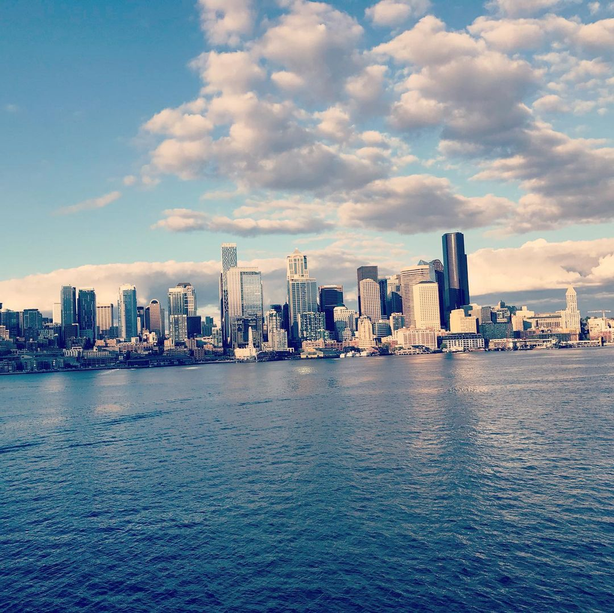

*Downtown Seattle, viewed from the Seattle-Bainbridge Ferry, WA.*

#### **NOAA Fisheries’ Alaska Fisheries Science Center, Resource Assessment and Conservation Engineering Division, Groundfish Assessment Program.**

#### **2020 - Present. Seattle, WA.**

- Assist in planning of and participate aboard the Eastern Bering Sea Shelf Bottom Trawl Survey, Eastern Bering Sea Slope, and Arctic Bottom Trawl Surveys.
- Assist in data collection and pre- and post-cruise data management for surveys and field research activities.
- Advance species distribution modeling research using model-based estimates of abundance and biomass using VAST, Generalized Additive Mixed Models (GAMMs), and other techniques.
- Aid in the development of R products that advance GAP surveys, modeling activities, and automation of reports and data products.
- Assist with the production of educational and informational outreach materials for engaging Alaska native communities about the Bering Sea surveys.

## Environmental Policy Analyst

[figure not shown]

*The NOAA hand outside of Building 3, Silver Spring, MD.*

#### **NOAA Fisheries’ Office of Science and Technology, Division of Economics and Social Analysis, Contractor through ECS Federal.**

#### **2019 - 2020. Silver Spring, MD.**

- Manage the production and publishing of the annual Fisheries Economics of the US Report (FEUS).
- Redevelop a commercial, recreation, and aquaculture national I/O model impact calculator model as an RShiny application to assist fisheries scientists and managers assess the impacts of changing fisheries.
- Develop the national fisheries economic productivity Tornqvist index output and organizing two fisheries economic productivity workshops for NOAA scientists.

## 2018 Knauss Marine Policy Fellow

[figure not shown]

*The announcement flyer for the 2018 Knauss Cohort.*

#### **Markowitz, EH, M Frisk, S Sagarese, JA Nye.**

#### **2018 - 2019. Silver Spring, MD.**

- Lead Coordinator, Protected Species Assessment Workshop II (PSAW II/#PSAW2019). 150+ person event, La Jolla, CA February 2019.
- Lead Coordinator, National Protected Species Toolbox Initiative (NPST). Managing 7 individual projects from fisheries science centers around the country.
- Co-Lead Coordinator, 2018 Protected Species Toolbox Mini-Symposium II. Program Manager, Sea Turtle Assessment Internal Funding Allocation.
- Lead Coordinator, Sea Turtle Research Standard Methods. Technical Support, Sea Turtle & Marine Mammal Protected Species Climate Vulnerability Assessment.
- Prepared sensitivity attributes guidelines, webinar presentations, and population literature reviews.
- Editor, Science Connect Newsletter (via Constant Contact and GovDelivery)
- RShiny App Developer, NMFS’ Technical Guidance for Assessing the Effects of Anthropogenic Sound on Marine Mammal Hearing. App provides a calculator function and report for permit applications. Prepared working group/program terms of references, webpages, internal proposals, and final reports.

## Accelerated Master’s of Science in Marine Science

[figure not shown]

*Presenting my Master’s Thesis to my committee and peers.*

#### **Dr. Janet Nye, Quantitative Fisheries Ecology Laboratory.**

#### **2015 - 2018. Stony Brook University, NY.**

- Thesis: “Distribution Shifts Associated with Changing Environmental Parameters in Two Demersal Species: Summer Flounder (Paralichthys dentatus) & Black Sea Bass (Centropristis striata) on the NE US shelf.”
- Developed environmental preference and habitat suitability models from the NOAA NEFSC survey dataset and Regional Oceanographic Modeling System (ROMS) output in MATLAB and R.

## Bachelor of Science in Marine Science, Cum Laude

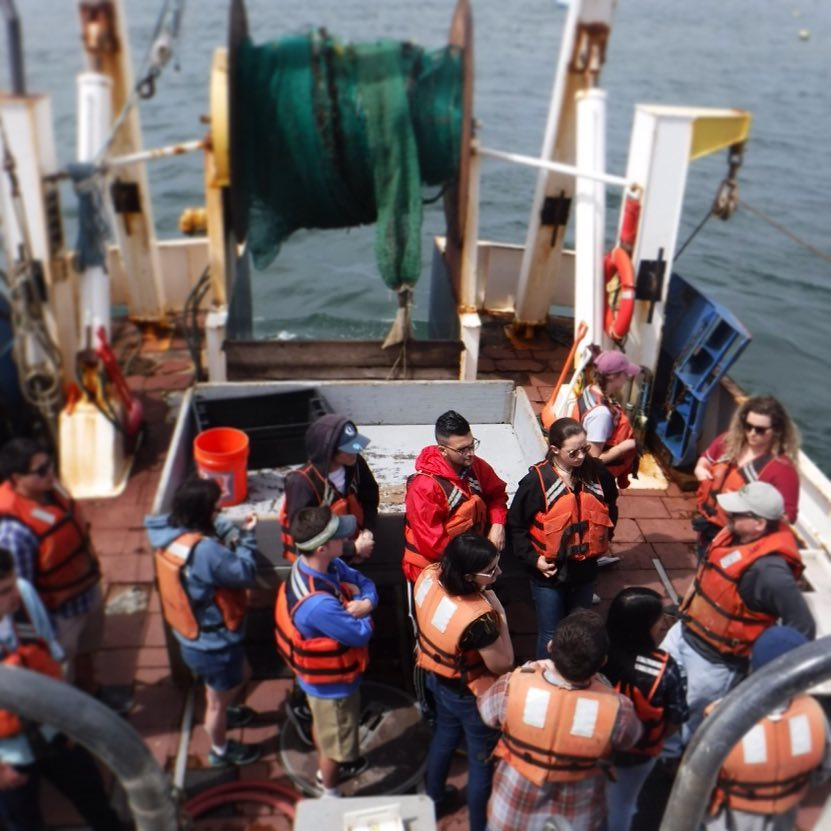

*Class in session on the deck of the* R/V Seawolf*.*

#### **Minors in Geospatial Information Sciences, Coastal Environmental Studies, and Theater Arts.**

#### **2011 - 2015. Stony Brook University, NY.**

- Crew member aboard the university resaerch vessel, the *R/V Seawolf*
- Dr. Joseph Warren, Acoustic Laboratory for Ecological Studies
- Dr. Bradley Peterson, Marine Community Ecology Laboratory, School of Marine and Atmospheric Sciences, Stony Brook, NY
- Dr. Steve Wing, University of Otago, Portobello Marine Laboratory, New Zealand
- Dr. Nathan Brennan, Mote Marine Laboratory Marine Aquaculture Park, Sarasota, FL
- Dr. Janet Nye, Quantitative Fisheries Ecology Laboratory, School of Marine and Atmospheric Sciences, Stony Brook, NY

[© Copyright 2024 Emily Markowitz](https://github.com/EmilyMarkowitz-NOAA/)